# R Notebook

Clear workspace:

```r
rm(list = ls())
```

Load libraries:

```r
library(data.table)
library(dplyr)
library(gdistance)
library(kableExtra)
library(raster)
library(rgdal)
library(sf)
library(tidyverse)
library(units)
```

# Load data

Load geography:

```r
load("population_sobi.RData") #interpolated population in SoBi area
load("sobi_hubs.RData") #location of SoBi hubs, minus Van Wagner's beach
load("sobi_hubs_original.RData") #SoBi hubs, minus ERI hubs
load("sobi_service.RData") #core service area for SoBi
load("ttm_walk.RData") #travel time matrix for interpolated population in SoBi area
load("ttm_walk_original.RData") #travel time matrix for system without ERI hubs
```

```r
summary(ttm_walk) #time is in minutes
```

```
      UID           OBJECTID       travel_time
 Min.   :   15   Min.   :  1.00   Min.   : 0.00
 1st Qu.: 3008   1st Qu.: 37.00   1st Qu.:14.00
 Median : 4951   Median : 69.00   Median :20.00
 Mean   : 5001   Mean   : 68.45   Mean   :18.86
 3rd Qu.: 6942   3rd Qu.:100.00   3rd Qu.:25.00
 Max.   :11305   Max.   :134.00   Max.   :29.00
```

Make a copy of the object for original system:

```r
population_sobi_original <- population_sobi
```

# Check the data

Plot the interpolated population:

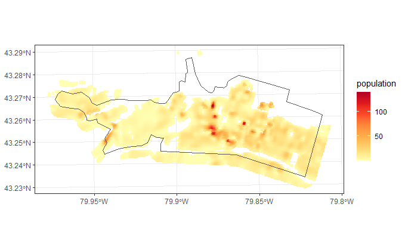

```r
ggplot(data = population_sobi) +
  geom_sf(aes(color = population)) +
  geom_sf(data = sobi_service,
          fill = NA) +
  scale_color_distiller(palette = "YlOrRd",
                        direction = 1)
```

Notice that the population units begin with UID 1 and ends with UID 11388:

```r
summary(population_sobi)
```

```
   population                geometry          UID
 Min.   :  0.0016   POINT        :11388   Min.   :    1
 1st Qu.:  4.7191   epsg:26917   :    0   1st Qu.: 2848
 Median :  9.8757   +proj=utm ...:    0   Median : 5694
 Mean   : 12.0857                         Mean   : 5694
 3rd Qu.: 15.5205                         3rd Qu.: 8541
 Max.   :140.1835                         Max.   :11388
```

The travel time table, on the other hand, begins with population UID 15 and ends with UID 11305:

```r
summary(ttm_walk)
```

```
      UID           OBJECTID       travel_time
 Min.   :   15   Min.   :  1.00   Min.   : 0.00
 1st Qu.: 3008   1st Qu.: 37.00   1st Qu.:14.00
 Median : 4951   Median : 69.00   Median :20.00
 Mean   : 5001   Mean   : 68.45   Mean   :18.86
 3rd Qu.: 6942   3rd Qu.:100.00   3rd Qu.:25.00
 Max.   :11305   Max.   :134.00   Max.   :29.00
```

What explains this discrepancy? We can compare the population units that are in the population dataset but not in the travel time table:

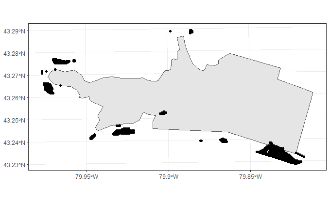

```r
ggplot() +
  geom_sf(data = sobi_service) +
  geom_sf(data = population_sobi %>%
            filter(!(UID %in% (distinct(ttm_walk, # filter observations with UIDs that are present in the travel time table
                                        UID) %>%
                                 pull(UID)))))
```

The reason that some population units do not appear in the travel time table is because they are outside of the service area of SoBi and/or cannot reach SoBi hubs by walking.

# Threshold

Calculate quantiles according to distance. This is done to select a threshold:

```r
quantiles_d <- quantile(as.vector(ttm_walk$travel_time), probs = c(0, 1/10, 3/10, 5/10, 7/10, 8/10, 9/10))

# dist_threshold <- quantile(as.vector(ttm_walk$travel_time), probs = c(0, 1/10, 3/10, 5/10, 7/10, 8/10, 9/10))[[5]]

# distance threshold has to be less than 30, maximum distance people are willing to go is distance threshold

dist_threshold <- 10
```

The distance threshold is equivalent to the *kernel bandwidth* or *catchment distance*.

# Set up matrix

Add population information:

```r
ttm_walk <- left_join(ttm_walk,
                      population_sobi,
                      by = "UID")
```

Drop the geometry:

```r
ttm_walk <- ttm_walk %>% dplyr::select(-geometry)
```

Add number of bicycle racks per SoBi hub as a measure of the level of supply:

```r
ttm_walk <- left_join(ttm_walk, sobi_hubs %>% dplyr::select(OBJECTID, RACKS_AMOU), by=c("OBJECTID" = "OBJECTID"))
ttm_walk <- ttm_walk %>% dplyr::select(-geometry)
head(ttm_walk)
```

|  | UID | OBJECTID | travel_time | population | RACKS_AMOU |
| --- | --- | --- | --- | --- | --- |
| 1 | 15 | 46 | 24 | 0.4976209 | 10 |
| 2 | 15 | 47 | 27 | 0.4976209 | 10 |
| 3 | 15 | 49 | 26 | 0.4976209 | 7 |
| 4 | 15 | 50 | 14 | 0.4976209 | 10 |
| 5 | 15 | 51 | 4 | 0.4976209 | 10 |
| 6 | 15 | 52 | 15 | 0.4976209 | 10 |

Rename columns:

```r
names(ttm_walk) <- c('UID', 'hub', 'travel_time', 'population', 'racks')
```

Calculate impedance (binary):

```r
# Run only if binary function desired
# Change chunk option eval=TRUE to FALSE if impedance is Gaussian function
ttm_walk <- ttm_walk %>%
  mutate(impedance_binary = ifelse(travel_time <= dist_threshold, 1, 0))
```

Check the value of the dist_threshold:

```r
dist_threshold
```

```
[1] 10
```

Calculate impedance (Gaussian):

```r
# Run only if Gaussian function desired
# Change chunk option eval=FALSE to TRUE if impedance is Gaussian function
ttm_walk <- ttm_walk %>%
  mutate(impedance_gaussian = case_when(travel_time <= quantiles_d[1] ~ 0.945,
                                        (travel_time > quantiles_d[1]) & (travel_time <= quantiles_d[3]) ~ 0.600,
                                        (travel_time > quantiles_d[3]) & (travel_time <= quantiles_d[5]) ~ 0.242,
                                        travel_time > quantiles_d[5] ~ 0))
```

Calculate the sum of the impedance by population for the balancing factors. In the binary case, this should be the same as the number of SoBi hubs that each interpolated population unit can reach; when the impedance is not binary, this is the sum of all impedance values:

```r
sum_b1 <- ttm_walk %>%
  group_by(UID) %>%
  summarize(sum_b1 = sum(impedance_binary),
            .groups = "drop")
sum_b1
```

| UID | sum_b1 |
| --- | --- |
| 15 | 2 |
| 16 | 2 |
| 17 | 2 |
| 18 | 3 |
| 29 | 0 |
| 30 | 0 |
| 31 | 3 |
| 32 | 2 |
| 33 | 3 |
| 34 | 3 |

[output cut: 990 more lines]

Sanity check: how many stations are within 24 minutes or less from population UID 15?

```r
ttm_walk %>%
  filter(UID == 15, travel_time <= 24) %>%
  nrow()
```

```
[1] 8
```

Calculate the sum of the impedance by SoBi hubs for the balancing factors. In the binary case, this should be the same as the number of interpolated population cells that each SoBi hub serves; when the impedance is not binary, this is the sum of all impedance values:

```r
sum_b2 <- ttm_walk %>%
  group_by(hub) %>%
  summarize(sum_b2 = sum(impedance_binary))
sum_b2
```

| hub | sum_b2 |
| --- | --- |
| 1 | 232 |
| 2 | 246 |
| 3 | 277 |
| 4 | 228 |
| 5 | 197 |
| 6 | 188 |
| 7 | 175 |
| 8 | 193 |
| 9 | 184 |
| 10 | 218 |

[output cut: 123 more lines]

Sanity check: how many population units are served by hub 1?

```r
ttm_walk %>%
  filter(hub == 1, travel_time <= 24) %>%
  nrow()
```

```
[1] 1502
```

Next, join the sum of the impedance to the table to calculate the balanced impedance values:

```r
ttm_walk <- ttm_walk %>%
  left_join(sum_b1, by = "UID") %>%
  left_join(sum_b2, by = "hub")
```

Check `sum_b1`:

```r
ttm_walk$sum_b1 %>%
  summary()
```

```
   Min. 1st Qu.  Median    Mean 3rd Qu.    Max.
  0.000   3.000   4.000   4.615   6.000  16.000
```

```r
ttm_walk <- ttm_walk %>%
  filter(sum_b1 > 0)
```

Are there any hubs that serve zero population units? (same issue with division by zero):

```r
ttm_walk$sum_b2 %>%
  summary()
```

```
   Min. 1st Qu.  Median    Mean 3rd Qu.    Max.
    8.0   213.0   263.0   245.7   284.0   334.0
```

No zeros or other strange values.

Calculate balanced impedance values:

```r
ttm_walk <- ttm_walk %>%
  mutate(balanced_impedance_1 = impedance_binary/sum_b1,
         balanced_impedance_2 = impedance_binary/sum_b2)
```

# Calculate level of service

Check the balanced_impedance factors for the population units:

```r
ttm_walk %>%
  dplyr::filter(hub == "46") %>%
  pull(balanced_impedance_2) %>%
  sum()
```

```
[1] 1
```

The sum should be 1.

[**Note: not sure if this step is needed for SoBi?** **Note for Elise: this is only an intermediate check in the analysis, it is not strictly necessary**] Notice that the population of each center is sorted among the SoBi hubs proportionally. Thanks to this property, the sum of the population serviced equals the total population in the system:

```r
ttm_walk %>%
  group_by(UID) %>%
  summarize(pop_served = sum(sum(population * balanced_impedance_1)),
            .groups = "drop") %>%
  pull(pop_served) %>%
  sum()
```

```
[1] 112929.4
```

```r
population_sobi %>%
  filter(UID %in% (distinct(ttm_walk,
                             UID) %>%
             pull(UID))) %>%
  pull(population) %>%
  sum()
```

```
[1] 112929.4
```

The level of service of each hub is the number of bicycle racks at the hub, divided by the population that they serve:

```r
sobi_los <- ttm_walk %>%
  dplyr::filter(impedance_binary > 0) %>% # filter impedance == 0 to avoid divisions by zero
  group_by(hub) %>%
  summarize(sobi_los = first(racks) / sum((population * balanced_impedance_1)),
            .groups = "drop")
sobi_los
```

| hub | sobi_los |
| --- | --- |
| 1 | 0.0628709934 |
| 2 | 0.0472630260 |
| 3 | 0.0327017496 |
| 4 | 0.0090434936 |
| 5 | 0.0054382100 |
| 6 | 0.0032187730 |
| 7 | 0.0111982058 |
| 8 | 0.0088590260 |
| 9 | 0.0505204308 |
| 10 | 0.0534378223 |

[output cut: 123 more lines]

Join the level of service to the table:

```r
ttm_walk <- ttm_walk %>%
  left_join(sobi_los, by = "hub")
```

# Calculate accessibility

To calculate accessibility, the level of service of each hub needs to be distributed proportionally to the population units.

```r
sobi_accessibility <- ttm_walk %>%
  group_by(UID) %>%
  summarize(accessibility = sum(sobi_los * balanced_impedance_2),
            .groups = "drop")
sobi_accessibility
```

| UID | accessibility |
| --- | --- |
| 15 | 0.000911932913 |
| 16 | 0.000911932913 |
| 17 | 0.000246767918 |
| 18 | 0.000956656851 |
| 31 | 0.000953055692 |
| 32 | 0.000911932913 |
| 33 | 0.000956656851 |
| 34 | 0.000956656851 |
| 35 | 0.000956656851 |
| 36 | 0.000956656851 |

[output cut: 990 more lines]

Check that the sum of the accessibility is equal to the available level of service:

```r
sobi_accessibility %>%
  pull(accessibility) %>%
  sum()
```

```
[1] 3.930199
```

```r
sobi_los %>%
  pull(sobi_los) %>%
  sum()
```

```
[1] 3.930199
```

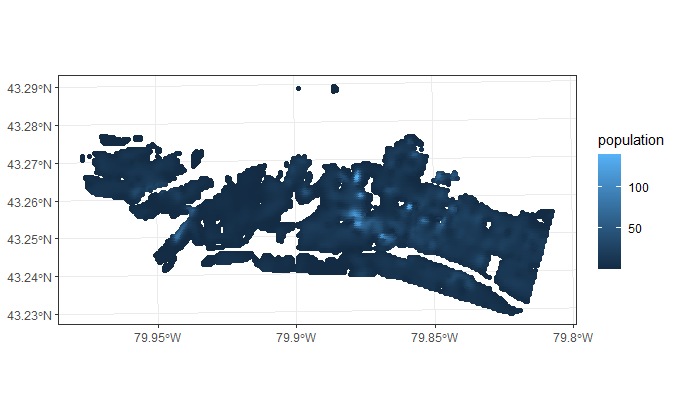

```r
ggplot(data = population_sobi) +
  geom_sf(aes(color = population))
```

Join the accessibility to the population units:

```r
population_sobi <- population_sobi %>%
  left_join(sobi_accessibility,
            by = "UID")
```

Plot accessibility:

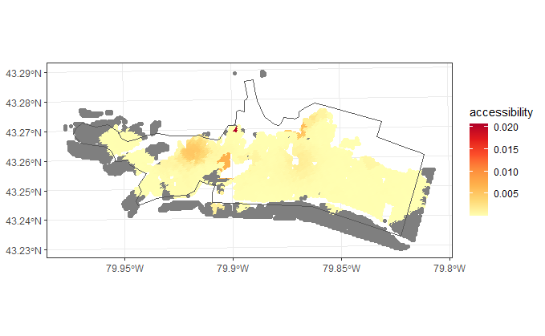

```r
ggplot(data = population_sobi) +
  geom_sf(aes(color = accessibility)) +
  geom_sf(data = sobi_service,
          fill = NA) +
  scale_color_distiller(palette = "YlOrRd",
                        direction = 1)
```

# Repeat above for the original SoBi system (no ERI hubs)

Calculate quantiles according to distance. This is done to select a threshold:

```r
quantiles_d_o <- quantile(as.vector(ttm_walk_o$travel_time), probs = c(0, 1/10, 3/10, 5/10, 7/10, 8/10, 9/10))

dist_threshold_o <- quantile(as.vector(ttm_walk_o$travel_time), probs = c(0, 1/10, 3/10, 5/10, 7/10, 8/10, 9/10))[[5]]
```

The distance threshold is equivalent to the *kernel bandwidth* or *catchment distance*.

# Set up matrix

Add population information:

```r
ttm_walk_o <- left_join(ttm_walk_o,
                      population_sobi_original,
                      by = "UID")
```

Drop the geometry:

```r
ttm_walk_o <- ttm_walk_o %>% dplyr::select(-geometry)
```

Add number of bicycle racks per SoBi hub as a measure of the level of supply:

```r
ttm_walk_o <- left_join(ttm_walk_o, sobi_hubs_original %>% dplyr::select(OBJECTID, RACKS_AMOU), by=c("OBJECTID" = "OBJECTID"))
ttm_walk_o <- ttm_walk_o %>% dplyr::select(-geometry)
head(ttm_walk_o)
```

|  | UID | OBJECTID | travel_time | population | RACKS_AMOU |
| --- | --- | --- | --- | --- | --- |
| 1 | 15 | 46 | 24 | 0.4976209 | 10 |
| 2 | 15 | 47 | 27 | 0.4976209 | 10 |
| 3 | 15 | 49 | 26 | 0.4976209 | 7 |
| 4 | 15 | 50 | 14 | 0.4976209 | 10 |
| 5 | 15 | 51 | 4 | 0.4976209 | 10 |
| 6 | 15 | 52 | 15 | 0.4976209 | 10 |

Rename columns:

```r
names(ttm_walk_o) <- c('UID', 'hub', 'travel_time', 'population', 'racks')
```

Calculate impedance (binary):

```r
# Run only if binary function desired
# Change chunk option eval=TRUE to FALSE if impedance is Gaussian function
ttm_walk_o <- ttm_walk_o %>%
  mutate(impedance_binary = ifelse(travel_time <= dist_threshold_o, 1, 0))
```

Check the value of the dist_threshold:

```r
dist_threshold_o
```

```
[1] 24
```

Our calculations assume that people do not go further than 24 min to reach a SoBi hub.

Calculate impedance (Gaussian):

```r
# Run only if Gaussian function desired
# Change chunk option eval=FALSE to TRUE if impedance is Gaussian function
ttm_walk_o <- ttm_walk_o %>%
  mutate(impedance_gaussian = case_when(travel_time <= quantiles_d_o[1] ~ 0.945,
                                        (travel_time > quantiles_d_o[1]) & (travel_time <= quantiles_d_o[3]) ~ 0.600,
                                        (travel_time > quantiles_d_o[3]) & (travel_time <= quantiles_d_o[5]) ~ 0.242,
                                        travel_time > quantiles_d_o[5] ~ 0))
```

Calculate the sum of the impedance by population for the balancing factors. In the binary case, this should be the same as the number of SoBi hubs that each interpolated population unit can reach; when the impedance is not binary, this is the sum of all impedance values:

```r
sum_b1 <- ttm_walk_o %>%
  group_by(UID) %>%
  summarize(sum_b1 = sum(impedance_binary),
            .groups = "drop")
sum_b1
```

| UID | sum_b1 |
| --- | --- |
| 15 | 8 |
| 16 | 6 |
| 17 | 8 |
| 18 | 8 |
| 29 | 0 |
| 30 | 0 |
| 31 | 11 |
| 32 | 10 |
| 33 | 10 |
| 34 | 10 |

[output cut: 990 more lines]

The interpolated population at unit 15 can reach eight SoBi hubs in 24 minutes, the population at unit 16 can reach six SoBi hubs, the population at unit 30 can reach zero hubs clinics, etc..

Sanity check: how many stations are within 24 minutes or less from population UID 15?

```r
ttm_walk_o %>%
  filter(UID == 15, travel_time <= 24) %>%
  nrow()
```

```
[1] 8
```

Calculate the sum of the impedance by SoBi hubs for the balancing factors. In the binary case, this should be the same as the number of interpolated population unit that each SoBi hub serves; when the impedance is not binary, this is the sum of all impedance values:

```r
sum_b2 <- ttm_walk_o %>%
  group_by(hub) %>%
  summarize(sum_b2 = sum(impedance_binary))
sum_b2
```

| hub | sum_b2 |
| --- | --- |
| 1 | 1502 |
| 2 | 1393 |
| 3 | 1478 |
| 4 | 1051 |
| 5 | 916 |
| 6 | 681 |
| 7 | 1090 |
| 8 | 783 |
| 9 | 1019 |
| 10 | 997 |

[output cut: 111 more lines]

Hub 1 serves 1502 interpolated population units, hub 2 serves 1393 population units, etc.

Sanity check: how many population units are served by hub 1?

```r
ttm_walk_o %>%
  filter(hub == 1, travel_time <= 24) %>%
  nrow()
```

```
[1] 1502
```

The values check.

Next, join the sum of the impedance to the table to calculate the balanced impedance values:

```r
ttm_walk_o <- ttm_walk_o %>%
  left_join(sum_b1, by = "UID") %>%
  left_join(sum_b2, by = "hub")
```

Check `sum_b1`:

```r
ttm_walk_o$sum_b1 %>%
  summary()
```

```
   Min. 1st Qu.  Median    Mean 3rd Qu.    Max.
   0.00   14.00   21.00   21.75   30.00   45.00
```

**Important:** notice that some values of `sum_b1` are zeros! This means that some population units cannot reach a SoBi hub in at most 24 min. Since the balancing impedance is calculated by diving the impedance by `sum_b1`, this will lead to NaNs (divisions by zero). To avoid issues we will remove any population units that reach zero hubs:

```r
ttm_walk_o <- ttm_walk_o %>%
  filter(sum_b1 > 0)
```

Are there any hubs that serve zero population units? (same issue with division by zero):

```r
ttm_walk_o$sum_b2 %>%
  summary()
```

```
   Min. 1st Qu.  Median    Mean 3rd Qu.    Max.
    216    1046    1225    1192    1393    1524
```

No zeros or other strange values.

Calculate balanced impedance values:

```r
ttm_walk_o <- ttm_walk_o %>%
  mutate(balanced_impedance_1 = impedance_binary/sum_b1,
         balanced_impedance_2 = impedance_binary/sum_b2)
```

# Calculate level of service

Check the balanced_impedance factors for the population units:

```r
ttm_walk_o %>%
  dplyr::filter(hub == "46") %>%
  pull(balanced_impedance_2) %>%
  sum()
```

```
[1] 1
```

The sum should be 1.

The level of service of each hub is the number of bicycle racks at the hub, divided by the population that they serve:

```r
sobi_los_original <- ttm_walk_o %>%
  dplyr::filter(impedance_binary > 0) %>% # filter impedance == 0 to avoid divisions by zero
  group_by(hub) %>%
  summarize(sobi_los_original = first(racks) / sum((population * balanced_impedance_1)),
            .groups = "drop")
sobi_los_original
```

| hub | sobi_los_original |
| --- | --- |
| 1 | 0.0153510895 |
| 2 | 0.0243564083 |
| 3 | 0.0183613796 |
| 4 | 0.0042290843 |
| 5 | 0.0049629164 |
| 6 | 0.0069478495 |
| 7 | 0.0060162959 |
| 8 | 0.0081819046 |
| 9 | 0.0140396094 |
| 10 | 0.0237360753 |

[output cut: 111 more lines]

Hub 1 has 0.01535 bicycles per person, hub 2 has 0.02435 bicycles per person, etc.

Join the level of service to the table:

```r
ttm_walk_o <- ttm_walk_o %>%
  left_join(sobi_los_original, by = "hub")
```

# Calculate accessibility

To calculate accessibility, the level of service of each hub needs to be distributed proportionally to the population units.

```r
sobi_accessibility_original <- ttm_walk_o %>%
  group_by(UID) %>%
  summarize(accessibility_o = sum(sobi_los_original * balanced_impedance_2),
            .groups = "drop")
sobi_accessibility_original
```

| UID | accessibility_o |
| --- | --- |
| 15 | 0.0003474428305 |
| 16 | 0.0003164776594 |
| 17 | 0.0003297698154 |
| 18 | 0.0003297698154 |
| 31 | 0.0004060113072 |
| 32 | 0.0004004490021 |
| 33 | 0.0003607349866 |
| 34 | 0.0003607349866 |
| 35 | 0.0003438266795 |
| 36 | 0.0003438266795 |

[output cut: 990 more lines]

Check that the sum of the accessibility is equal to the available level of service:

```r
sobi_accessibility_original %>%
  pull(accessibility_o) %>%
  sum()
```

```
[1] 1.974924
```

```r
sobi_los_original %>%
  pull(sobi_los_original) %>%
  sum()
```

```
[1] 1.974924
```

Compared to the analysis that includes the ERI hubs, the available level of service is lower.

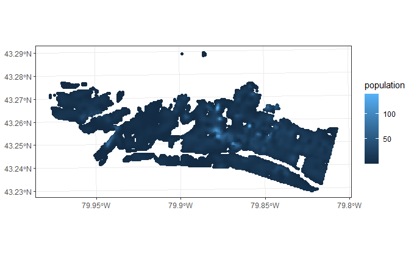

```r
ggplot(data = population_sobi_original) +
  geom_sf(aes(color = population))
```

Join the accessibility to the population units:

```r
population_sobi_original <- population_sobi_original %>% left_join(sobi_accessibility_original, by = "UID")
```

Plot accessibility:

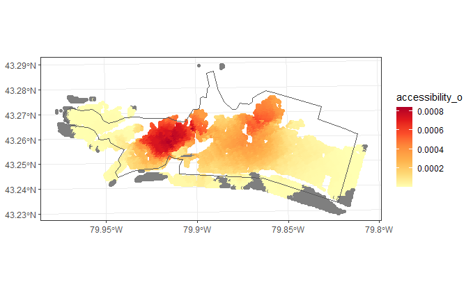

```r
ggplot(data = population_sobi_original) +
  geom_sf(aes(color = accessibility_o)) +
  geom_sf(data = sobi_service,
          fill = NA) +
  scale_color_distiller(palette = "YlOrRd",
                        direction = 1)
```

## Disparity Analysis

An advantage of the use of adjusted weights for proportional allocation of demand and level of service it that, after rectifying the inflation artifact, they make it is possible to conduct accessibility disparity analysis in a very intuitive way.

For instance, an analyst interested in equity analysis could allocate the total level of service uniformly to every population unit. In other words, the total level of service (which equals the sum of accessibility over the system) can be divided by the number of population units in the system to return the Average Local Population Unit PPR. The resulting mean value, call it $L_i^e$ then would be assigned to the population units as their “equitable” share of the total level of service in the system. Next, the equitable distribution of the level of service in each population unit is subtracted from the estimated accessibility to arrive at a disparity index. When the difference between these two quantities is positive, this would indicate that accessibility at that location exceeds its equitable share of level of service. On the other hand, when the difference is negative, accessibility at the location is below its equitable share of the level of service.

This approach is reminiscent of the Spatial Access Ratio (SPAR) proposed by Wan et al. [-@Wan2012SPAR], which is calculated as the ratio between a population center’s accessibility and the mean accessibility across all population centers. Wan et al. [-@Wan2012] calculate SPAR based on the results of their 3SFCA method, by re-scaling the accessibility measures to reflect the percentage difference in each population center’s accessibility relative to the mean. This measure is designed to overcome the sensitivity of existing FCA metrics to the impedance function. In contrast, the approach proposed here, enables more intuitive and interpretable results by preserving the system-wide population and level of service. In this way, a disparity index is useful to highlight the absolute difference in accessible provider-to-population ratios across population units.

The disparity for SoBi is shown in the following map. The figure reveals the spatial distribution in disparity, with levels of access that are lower than the mean in the periphery of the service area, compared to levels of access that are greater than the mean in the higher-density and more connected urban center. It is worth noting that levels of access that are greater than the mean are predominantly concentrated around the University in west Hamilton. Areas that have less than their equitable share of the level of service are some of the most socioeconomically disadvantaged areas in the city. Our analysis builds upon a previous and recent study [@hosfordWhoArePublic2018] which found that disadvantaged areas in Hamilton are better served by the SoBi system, compared to other Canadian cities [i.e., Toronto, Vancouver, Montreal, and Ottawa-Gatineau] where advantaged areas have greater access. The authors [@hosfordWhoArePublic2018] note “Hamilton stands out in that the lower income neighborhoods are located near the city center and wealthier neighborhoods are in the surrounding suburban areas. Thus, relative to other Canadian programs, Hamilton’s bicycle share program could more easily be established in lower income areas while still being near high population density areas”. This is an artifact of the 2001 amalgamation of Hamilton with four surrounding communities. The urban core, which is Hamilton proper, remains predominantly disadvantaged compared to the 4 amalgamated and less densely populated areas (e.g., Dundas, Ancaster, Stoney Creek, Waterdown) that surround the city. Interestingly, Dundas is an advantaged area but also has lower accessibility that is less than their equitable share. However, by calculating the disparity index, we have shown that more advantaged areas within the SoBi service area have higher levels of service and exceed its equitable share of service.

## Disparity of system with ERI hubs

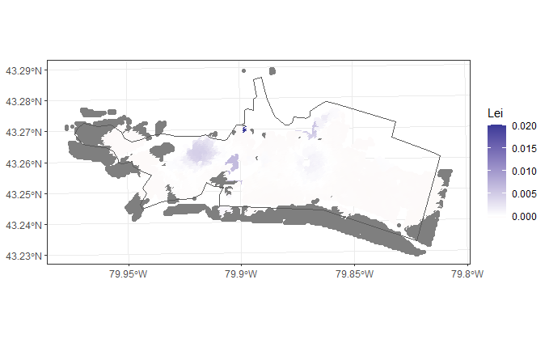

```r
population_sobi %>%
  mutate(Lei = accessibility - sum(sobi_los$sobi_los)/nrow(population_sobi %>% drop_na(accessibility))) %>%
  ggplot() +
  geom_sf(aes(color = Lei)) +
  geom_sf(data = sobi_service,
          fill = NA) +
  scale_color_gradient2()
```

Drop population units that have `NA` for accessibility because they are outside of the service area of SoBi and/or cannot reach SoBi hubs by walking.

```r
population_sobi <- population_sobi %>% drop_na()
```

This data frame now has the same number of rows as the data frame on `sobi_accessibility`.

Calculate the sum of accessibility over the system:

```r
sum(population_sobi$accessibility)
```

```
[1] 3.930199
```

Divide by the number of population units in the system to return the average local population unit provider-to-population ratio:

```r
population_sobi <- population_sobi %>% mutate(PPR = sum(accessibility/nrow(population_sobi)))
```

Check plot:

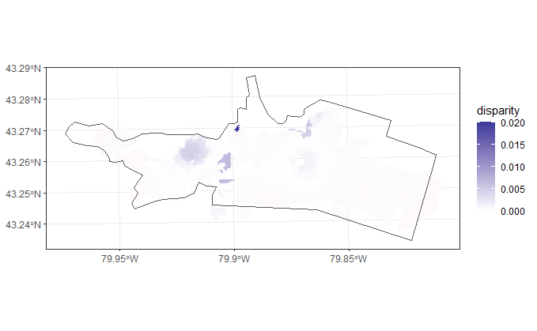

```r
population_sobi %>%
  ggplot() +
  geom_sf(aes(color = disparity)) +
  geom_sf(data = sobi_service,
          fill = NA) +
  scale_color_gradient2()
```

## Disparity of original system without ERI hubs

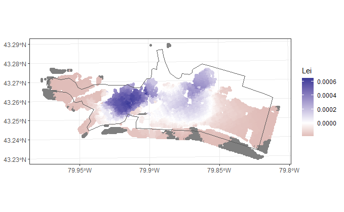

```r
population_sobi_original %>%
  mutate(Lei = accessibility_o - sum(sobi_los_original$sobi_los_original)/nrow(population_sobi_original %>% drop_na(accessibility_o))) %>%
  ggplot() +
  geom_sf(aes(color = Lei)) +
  geom_sf(data = sobi_service,
          fill = NA) +
  scale_color_gradient2()
```

Drop population units that have `NA` for accessibility because they are outside of the service area of SoBi and/or cannot reach SoBi hubs by walking.

```r
population_sobi_original <- population_sobi_original %>% drop_na()
```

This data frame now has the same number of rows as the data frame on `sobi_accessibility_original`.

Calculate the sum of accessibility over the system:

```r
sum(population_sobi_original$accessibility_o)
```

```
[1] 1.974924
```

Divide by the number of population units in the system to return the average local population unit provider-to-population ratio:

```r
population_sobi_original <- population_sobi_original %>% mutate(PPR_o = sum(accessibility_o/nrow(population_sobi_original)))
```

The “equitable” share of the total level of service in the system is 0.0001927507 per population unit.

Check plot:

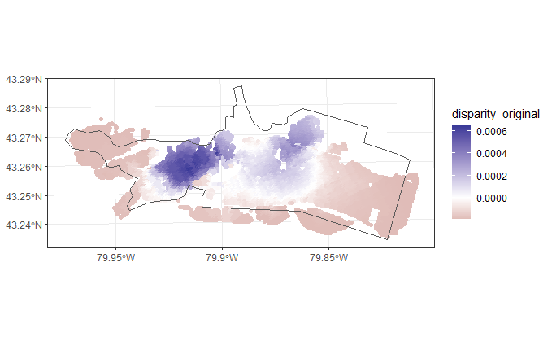

```r
population_sobi_original %>%
  ggplot() +
  geom_sf(aes(color = disparity_original)) +
  geom_sf(data = sobi_service,
          fill = NA) +
  scale_color_gradient2()
```

Join in one data frame:

```r
sobi_equity <- population_sobi_original %>% st_join(population_sobi, by = "UID")
```

Drop duplicate population and UID columns:

```r
sobi_equity <- sobi_equity[ -c(6, 7) ]
```

Rename columns:

```r
names(sobi_equity) <- c('population', 'UID', 'accessibility_o', 'PPR_o', 'disparity_o', 'accessibility', 'PPR', 'disparity', 'geometry')
```

Calculate difference in disparity between system with and without ERI hubs:

```r
sobi_equity <- sobi_equity %>% mutate(disparity_change = disparity - disparity_o)
```

Check plot:

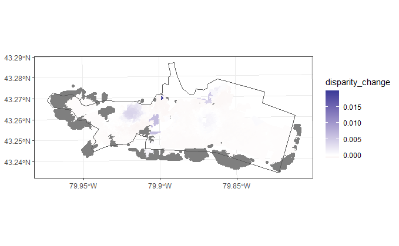

```r
sobi_equity %>%
  ggplot() +
  geom_sf(aes(color = disparity_change)) +
  geom_sf(data = sobi_service,
          fill = NA) +
  scale_color_gradient2()
```

Save data file:

```r
save(sobi_equity, file = "sobi_equity.RData")
```